# proj climate model outputs

#### organize and compare rhessys model outputs

- spin up was from 1940 - 2010 with historic climate data for downtown Santa Barbara

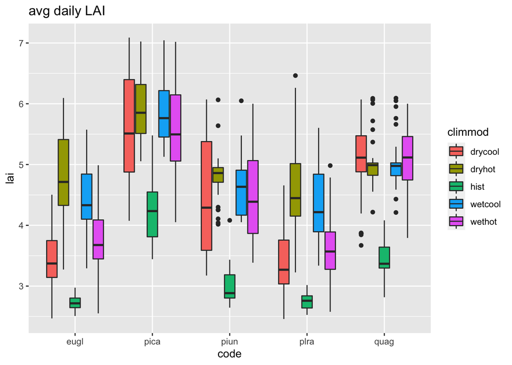

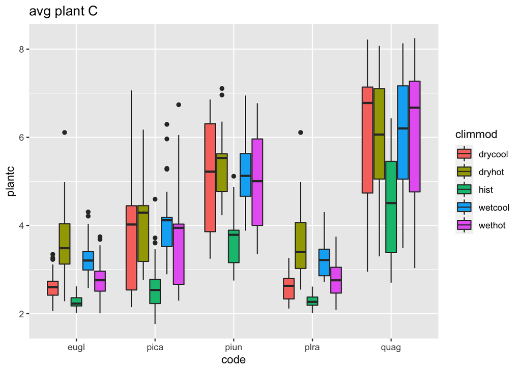

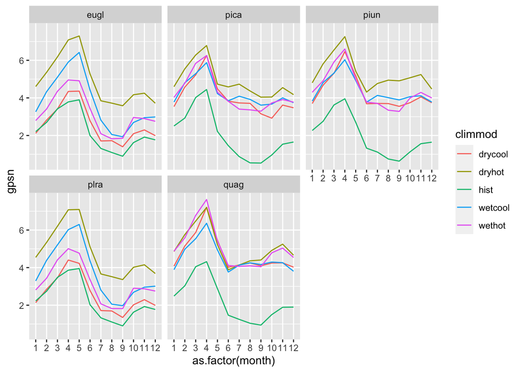

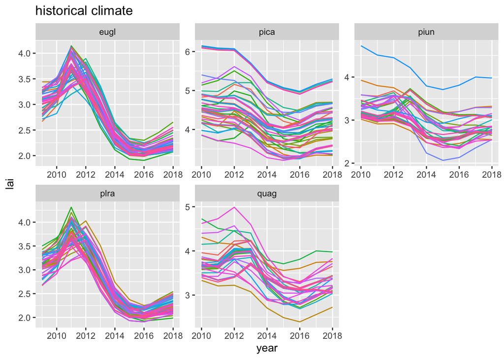

#### historic annual clim anomalies

Note that the drought is considered to be from 2012-2016, with wy 2014 the most extreme hot/dry concurrent event.

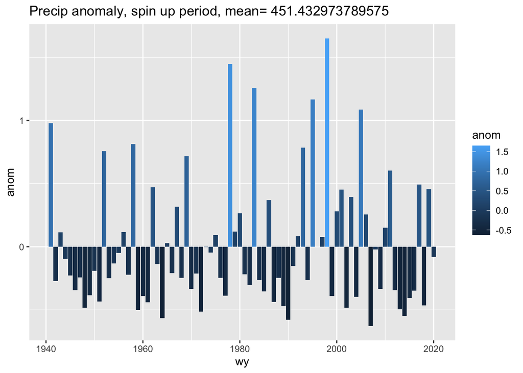

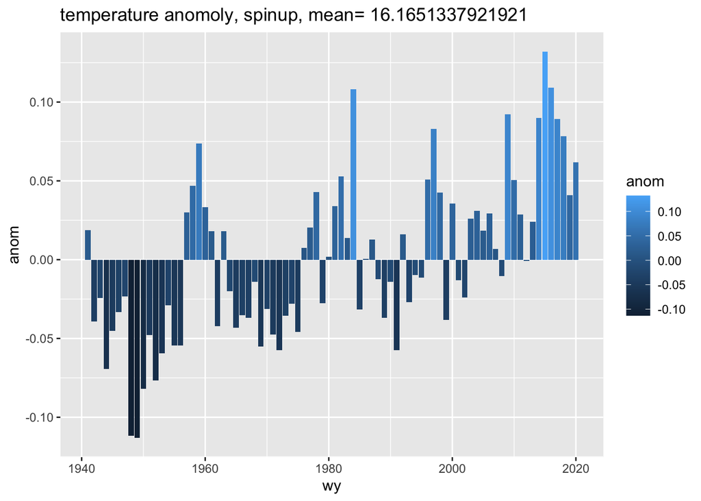

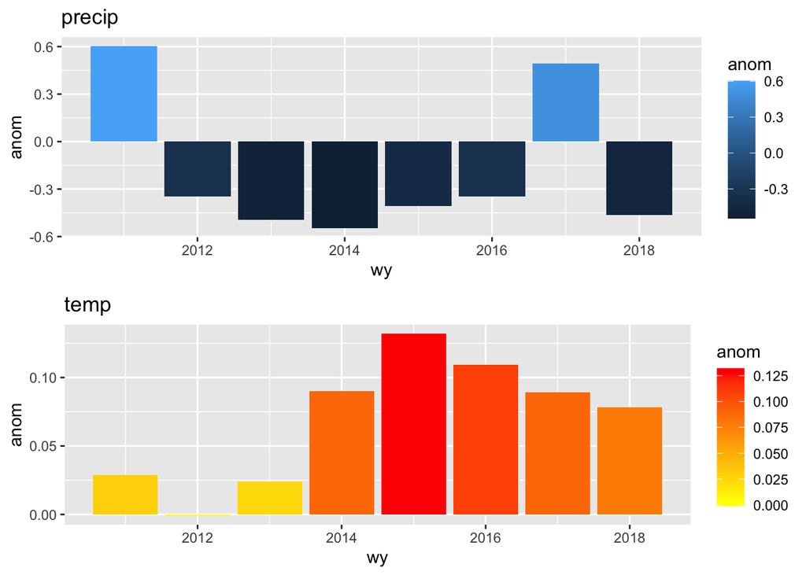

Should T anomaly be averaged for only summer or winter months instead of the whole year?

#### More extreme climate scenarios

main question: does it make sense to use climate projections here, or is it easier to manually change the historic data to be the same pattern, just % larger or smaller magnitude?

1. hotter
- relatively same precip, but varying temp
- if temperature was twice as hot, or double the anomaly
- various % of that temperature increasing

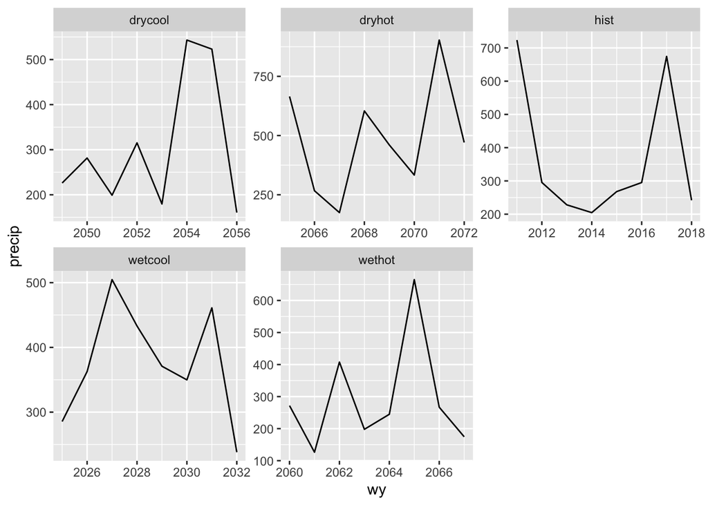

```r
readout <- mkwy(readout)

readout %>% dplyr::filter(code=='quag' & run==1) %>%
  group_by(wy, climmod) %>% summarize_at(vars(precip), list(sum)) %>%
  ggplot() + geom_line(aes(x=wy, y=precip)) + facet_wrap('climmod', scales='free')
```

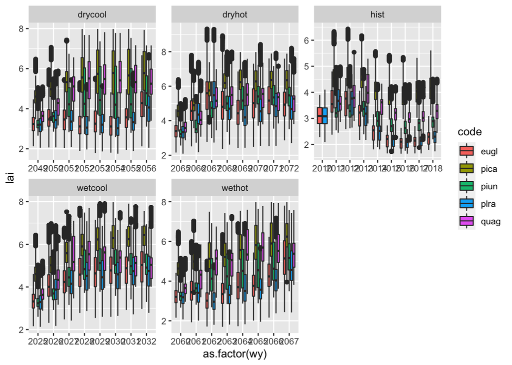

```r
ggplot(readout) + geom_boxplot(aes(x=as.factor(wy), y=lai, fill=code)) + facet_wrap('climmod', scales='free')
```

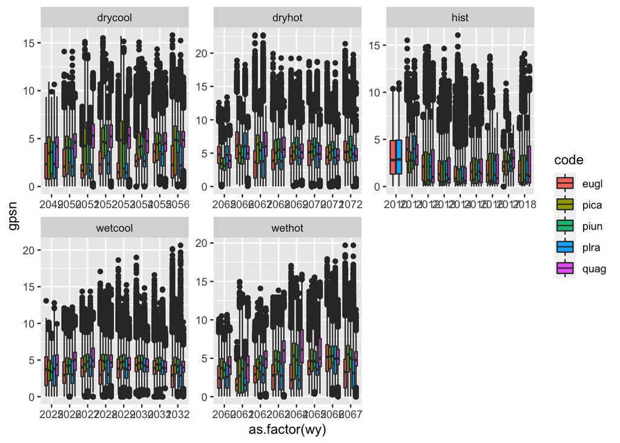

```r
ggplot(readout) + geom_boxplot(aes(x=as.factor(wy), y=gpsn, fill=code)) + facet_wrap('climmod', scales='free')
```

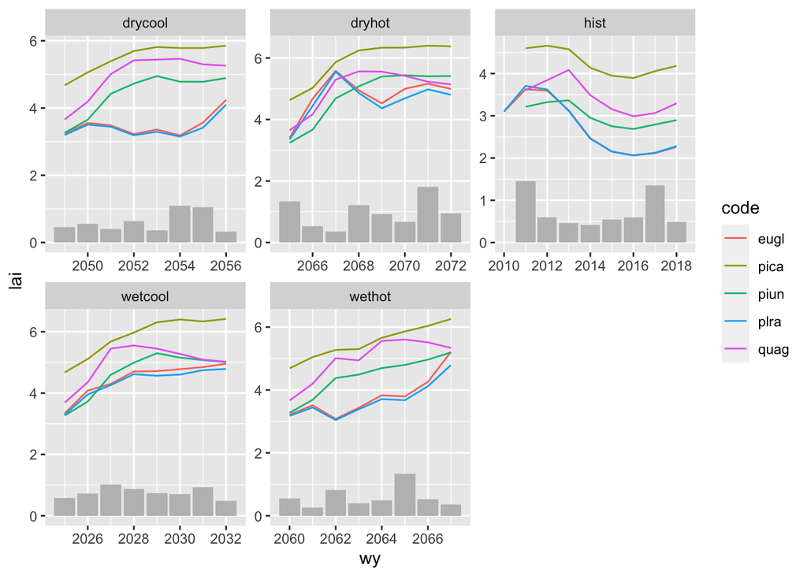

```r
readout %>% group_by(wy, code, climmod) %>%
  summarize(lai=mean(lai)) %>%
  ggplot() + geom_line(aes(
    x=wy, y=lai, col=code)) +
  facet_wrap("climmod", scales='free') +
  geom_col(data=readout[readout$run==1 & readout$code=='quag',], aes(x=wy, y=precip/500), fill='grey')
```

output of the different scenarios